# Object Detection on EO Imagery

### YOLOv8 (NWPU VHR-10 Dataset)

## Objective

This notebook evaluates object detection on very high-resolution Earth Observation imagery using YOLOv8.

We focus on:

- multi-class object detection in aerial imagery
- localization and classification performance
- controlled comparison of training settings

Goal: understand how image size, augmentation, and training duration affect detection performance on EO data.

## Workflow

1. Data loading and inspection
2. Dataset preparation in YOLO format
3. YOLOv8 training
4. Performance evaluation (mAP) and error analysis (precision–recall)
5. Prediction visualization

## Dataset

We use the NWPU VHR-10 object detection dataset:

- very high-resolution optical aerial imagery (RGB)
- bounding box annotations
- 10 target object classes
- multi-class EO object detection task
- Resized to a consistent input size

The dataset is split into training, validation, and test sets.

## Data Inspection

Visual inspection to verify image quality, class coverage, bounding-box annotations

```python
import torch, torchvision, torchgeo
print("PyTorch:", torch.__version__)
print("TorchVision:", torchvision.__version__)
print("TorchGeo:", torchgeo.__version__)
```

```
PyTorch: 2.10.0+cu126
TorchVision: 0.25.0+cu126
TorchGeo: 0.9.0
```

```python
import os, random, json, warnings, math, shutil
from pathlib import Path
from dataclasses import dataclass

import numpy as np
import matplotlib.pyplot as plt
from matplotlib.patches import Rectangle

import torch
from torch.utils.data import DataLoader
import torchvision.transforms.functional as TF

from torchgeo.datasets import VHR10

try:
    from ultralytics import YOLO
    _ultra_ok = True
except Exception as e:
    _ultra_ok = False
    print("Ultralytics not found. If needed, install with: pip install ultralytics")

warnings.filterwarnings("ignore")

SEED = 42
random.seed(SEED); np.random.seed(SEED); torch.manual_seed(SEED)

device = torch.device("cuda" if torch.cuda.is_available() else "cpu")
print("Using device:", device)
```

```
Using device: cuda
```

```
Files already downloaded and verified
loading annotations into memory...
Done (t=0.04s)
creating index...
index created!
Total images: 650
Classes: ['Airplanes', 'Ships', 'Storage tanks', 'Baseball diamonds', 'Tennis courts', 'Basketball courts', 'Ground track fields', 'Harbors', 'Bridges', 'Vehicles']
```

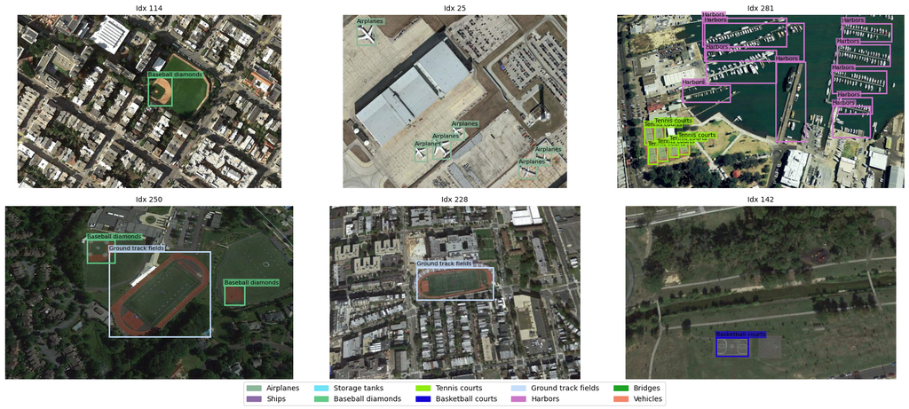

```python
# Load NWPU VHR-10 dataset (high-resolution aerial object detection)
DATA_ROOT = Path("./data/vhr10")
DATA_ROOT.mkdir(parents=True, exist_ok=True)

try:
    ds_all = VHR10(root=DATA_ROOT, download=True)
except TypeError:
    ds_all = VHR10(root=DATA_ROOT)

print("Total images:", len(ds_all))

classes = [
    "Airplanes",
    "Ships",
    "Storage tanks",
    "Baseball diamonds",
    "Tennis courts",
    "Basketball courts",
    "Ground track fields",
    "Harbors",
    "Bridges",
    "Vehicles"
]
num_classes = len(classes)
print("Classes:", classes)

# Visualize random samples with ground-truth bounding boxes and legend

N_SHOW = min(6, len(ds_all))
indices = random.sample(range(len(ds_all)), N_SHOW)

np.random.seed(0)
palette = np.random.rand(num_classes, 3)

fig, axes = plt.subplots(2, (N_SHOW+1)//2, figsize=(18, 8))
axes = axes.flatten()

for ax, idx in zip(axes, indices):
    sample = ds_all[idx]
    img = sample["image"]
    boxes = sample["bbox_xyxy"]
    labels = sample["label"].tolist()

    if isinstance(img, torch.Tensor):
        img = img.permute(1, 2, 0).numpy()
    elif isinstance(img, np.ndarray) and img.ndim == 3 and img.shape[0] in [1, 3]:
        img = np.transpose(img, (1, 2, 0))

    ax.imshow(img.astype(np.uint8))
    ax.axis("off")
    ax.set_title(f"Idx {idx}", fontsize=10)
    for b, lab in zip(boxes, labels):
        lab = int(lab) - 1
        x1, y1, x2, y2 = [float(v) for v in b.tolist()]
        rect = Rectangle((x1, y1), x2-x1, y2-y1,
                         fill=False, lw=2, color=palette[lab])
        ax.add_patch(rect)
        ax.text(
                x1, max(y1 - 5, 5), classes[lab],
                color="black", fontsize=8,
                bbox=dict(facecolor=palette[lab], alpha=0.7, edgecolor="none", pad=1.5)
            )
handles = [Rectangle((0,0),1,1, color=palette[i], fill=True) for i in range(num_classes)]
fig.legend(handles, classes, loc="lower center", ncol=min(num_classes, 5))
plt.tight_layout(rect=(0,0.05,1,1))
plt.show()
```

## Export to YOLO Format

YOLOv8 requires normalized bounding-box annotations in YOLO format.

```python
# Split dataset (60/20/20)
all_indices = list(range(len(ds_all)))
random.shuffle(all_indices)
n_total = len(all_indices)
n_train = int(0.6 * n_total)
n_val   = int(0.2 * n_total)

train_idx = all_indices[:n_train]
val_idx   = all_indices[n_train:n_train+n_val]
test_idx  = all_indices[n_train+n_val:]

print(f"Train: {len(train_idx)}, Val: {len(val_idx)}, Test: {len(test_idx)}")
```

```
Train: 390, Val: 130, Test: 130
```

```python
# Export to YOLO detection format
YOLO_ROOT = Path("./data/vhr10_yolo")

if YOLO_ROOT.exists():
    shutil.rmtree(YOLO_ROOT)

for sub in ["images/train","images/val","images/test","labels/train","labels/val","labels/test"]:
    (YOLO_ROOT / sub).mkdir(parents=True, exist_ok=True)

from PIL import Image

def save_sample_to_yolo(sample, img_out_path, label_out_path):
    img = sample["image"]
    boxes = sample["bbox_xyxy"]
    labels = sample["label"]

    if isinstance(img, torch.Tensor):
        # (C, H, W) -> (H, W, C)
        img = img.permute(1, 2, 0).numpy()
        img = Image.fromarray(img.astype(np.uint8))

    img.save(img_out_path, format="JPEG", quality=95)

    W, H = img.size
    with open(label_out_path, "w") as f:
        for b, lab in zip(boxes, labels):
            # Convert (x1, y1, x2, y2) → (cx, cy, w, h) normalized by image size
            lab = int(lab) - 1
            x1, y1, x2, y2 = [float(v) for v in b.tolist()]
            cx = (x1 + x2) / 2.0 / W
            cy = (y1 + y2) / 2.0 / H
            bw = (x2 - x1) / W
            bh = (y2 - y1) / H
            cx = min(max(cx, 0.0), 1.0)
            cy = min(max(cy, 0.0), 1.0)
            bw = min(max(bw, 0.0), 1.0)
            bh = min(max(bh, 0.0), 1.0)
            f.write(f"{lab} {cx:.6f} {cy:.6f} {bw:.6f} {bh:.6f}\n")

def export_split(indices, split):
    for idx in indices:
        sample = ds_all[idx]
        img_name = f"{split}_{idx}.jpg"
        label_name = f"{split}_{idx}.txt"
        save_sample_to_yolo(sample, YOLO_ROOT/f"images/{split}/{img_name}", YOLO_ROOT/f"labels/{split}/{label_name}")

export_split(train_idx, "train")
export_split(val_idx,   "val")
export_split(test_idx,  "test")

dataset_yaml = {
    "path": str(YOLO_ROOT.resolve()),
    "train": "images/train",
    "val": "images/val",
    "test": "images/test",
    "names": {i: cls for i, cls in enumerate(classes)}
}
with open(YOLO_ROOT/"dataset.yaml", "w") as f:
    json.dump(dataset_yaml, f, indent=2)

print("YOLO dataset prepared at:", YOLO_ROOT)
```

```
YOLO dataset prepared at: data\vhr10_yolo
```

## Training

YOLOv8 models (v8n, v8s) were trained for 10–50 epochs under different input resolutions (416 → 512 → 640) to evaluate performance scaling.

```python
# Train YOLOv8 model on VHR-10
assert _ultra_ok, "Ultralytics not installed. Run: pip install ultralytics"

data_yaml = str((YOLO_ROOT / "dataset.yaml").resolve())
model = YOLO("yolov8s.pt")

results = model.train(
    data=data_yaml,
    epochs=50,
    imgsz=640,
    scale=0.2,
    translate=0.2,
    device=0 if torch.cuda.is_available() else "cpu",
    project="runs_vhr10",
    name="yolov8s_640_vhr10",
    exist_ok=True,
    verbose=False
    )
print("Training finished.")
```

[output not shown]

[output cut: 259 more lines]

```
                 Class     Images  Instances      Box(P          R      mAP50  mAP50-95): 100% ━━━━━━━━━━━━ 5/5 3.0it/s 1.7s0.5s
                   all        130        780      0.969      0.927      0.958      0.755

50 epochs completed in 0.198 hours.
Optimizer stripped from C:\Users\pprum\OneDrive\Desktop\CV_Prum\AI4EO\runs\detect\runs_vhr10\yolov8s_640_vhr10\weights\last.pt, 22.5MB
Optimizer stripped from C:\Users\pprum\OneDrive\Desktop\CV_Prum\AI4EO\runs\detect\runs_vhr10\yolov8s_640_vhr10\weights\best.pt, 22.5MB

Validating C:\Users\pprum\OneDrive\Desktop\CV_Prum\AI4EO\runs\detect\runs_vhr10\yolov8s_640_vhr10\weights\best.pt...
Ultralytics 8.4.21  Python-3.12.3 torch-2.10.0+cu126 CUDA:0 (NVIDIA GeForce RTX 3070 Laptop GPU, 8192MiB)
Model summary (fused): 73 layers, 11,129,454 parameters, 0 gradients, 28.5 GFLOPs
                 Class     Images  Instances      Box(P          R      mAP50  mAP50-95): 100% ━━━━━━━━━━━━ 5/5 2.2it/s 2.3s0.8s
                   all        130        780      0.968      0.932       0.96      0.759
Speed: 0.2ms preprocess, 3.4ms inference, 0.0ms loss, 6.9ms postprocess per image
Results saved to C:\Users\pprum\OneDrive\Desktop\CV_Prum\AI4EO\runs\detect\runs_vhr10\yolov8s_640_vhr10
Training finished.
```

## Evaluation

- mAP50–95: primary metric, averages performance across IoU thresholds (0.50–0.95), providing a stricter and more comprehensive evaluation
- mAP50: reported for comparison, reflects detection under a relaxed overlap criterion (IoU = 0.50)
- Precision–Recall: used for class-wise analysis to examine the trade-off between false positives and missed detections

```python
# Evaluate trained YOLOv8 model on test split (mAP metrics)
best_w = Path("runs/detect/runs_vhr10/yolov8s_640_vhr10/weights/best.pt")
if not best_w.exists():
    best_w = Path("runs/detect/runs_vhr10/yolov8s_640_vhr10/weights/last.pt")

model = YOLO(str(best_w))
test_metrics = model.val(data=str((YOLO_ROOT/"dataset.yaml").resolve()), split="test", imgsz=640, device=0 if torch.cuda.is_available() else "cpu",
                         exist_ok=True)

metrics = test_metrics.results_dict if hasattr(test_metrics, "results_dict") else {}
map50_95 = metrics.get("metrics/mAP50-95(B)", None)
map50 = metrics.get("metrics/mAP50(B)", None)

print(f"Test mAP50-95: {map50_95:.4f}" if map50_95 is not None else "mAP50-95 not found in results.")
print(f"Test mAP50: {map50:.4f}" if map50 is not None else "mAP50 not found in results.")
```

```
Ultralytics 8.4.21  Python-3.12.3 torch-2.10.0+cu126 CUDA:0 (NVIDIA GeForce RTX 3070 Laptop GPU, 8192MiB)
Model summary (fused): 73 layers, 11,129,454 parameters, 0 gradients, 28.5 GFLOPs
val: Fast image access  (ping: 0.10.0 ms, read: 23.87.8 MB/s, size: 202.1 KB)
val: Scanning C:\Users\pprum\OneDrive\Desktop\CV_Prum\AI4EO\data\vhr10_yolo\labels\test... 130 images, 0 backgrounds, 0 corrupt: 100% ━━━━━━━━━━━━ 130/130 367.2it/s 0.4s0.1s
val: New cache created: C:\Users\pprum\OneDrive\Desktop\CV_Prum\AI4EO\data\vhr10_yolo\labels\test.cache
                 Class     Images  Instances      Box(P          R      mAP50  mAP50-95): 100% ━━━━━━━━━━━━ 9/9 1.1it/s 8.1s0.3ss
                   all        130        647      0.951      0.913      0.954      0.749
             Airplanes         15        112      0.972      0.991      0.994      0.823
                 Ships         11         61      0.872      0.852      0.926      0.695
         Storage tanks          3         94      0.965          1      0.984       0.77
     Baseball diamonds         37         70      0.958      0.967      0.988      0.901
         Tennis courts         19         97      0.938      0.773      0.884      0.681
     Basketball courts         17         28      0.966      0.964      0.968      0.849
   Ground track fields         35         35      0.963          1      0.995       0.95
               Harbors          7         49      0.933      0.856      0.892      0.643
               Bridges         14         23      0.985      0.783      0.935       0.47
              Vehicles         15         78      0.961      0.939      0.971      0.703
Speed: 2.4ms preprocess, 13.7ms inference, 0.0ms loss, 3.4ms postprocess per image
Results saved to C:\Users\pprum\OneDrive\Desktop\CV_Prum\AI4EO\runs\detect\val
Test mAP50-95: 0.7485
Test mAP50: 0.9537
```

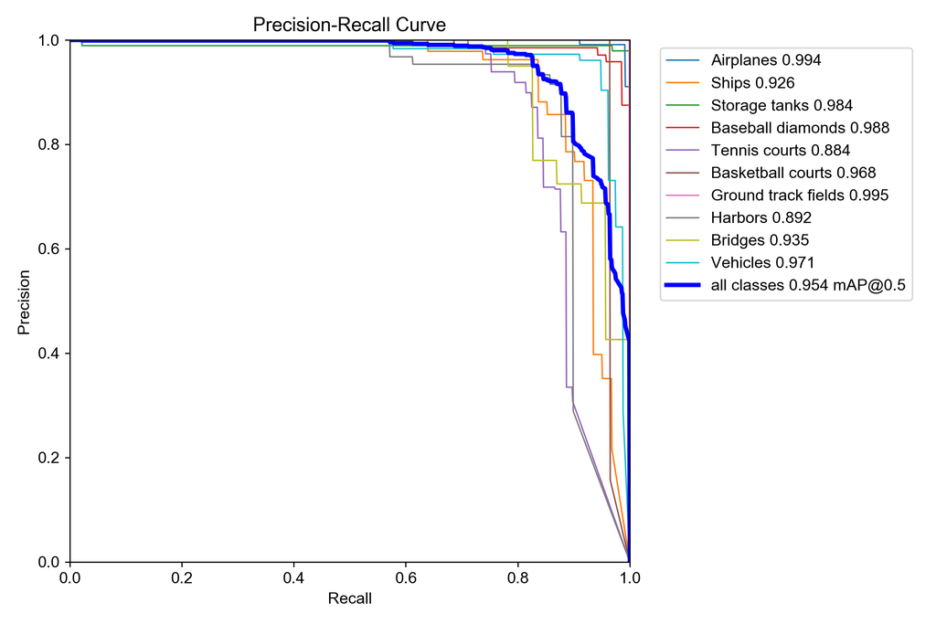

```python
from IPython.display import Image, display

# 1. Precision–Recall Curve (core metric)
display(Image(filename="runs/detect/val/BoxPR_curve.png", width=500))
```

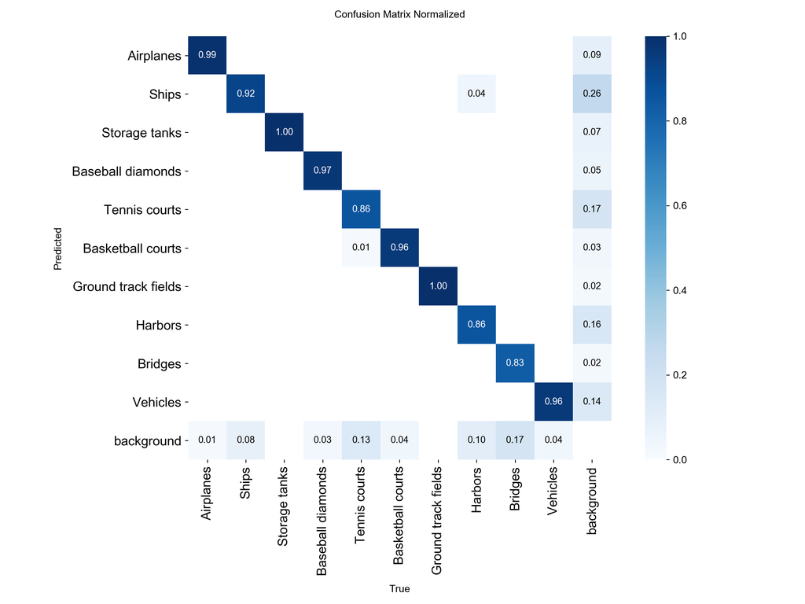

```python
# 2. Normalized Confusion Matrix (error structure)
display(Image(filename="runs/detect/val/confusion_matrix_normalized.png", width=500))
```

## Class-wise Performance Analysis

- High-performing classes (AP ≥ 0.98): airplanes, storage tanks, baseball diamonds, ground track fields  
  → large or structurally distinctive objects with clear visual patterns, making them easier to detect reliably
- Moderate-performing classes (0.90 ≤ AP < 0.98): ships, basketball courts, bridges, vehicles  
  → generally detectable, but performance is affected by smaller object size, scene complexity, or shape variability
- Lower-performing classes (AP < 0.90): tennis courts, harbors  
  → more challenging due to confusing background context, structural similarity to surrounding objects, and less consistent separability
- Precision–Recall behavior:
  - High precision, lower recall → bridges, tennis courts  
    (the model is conservative: when it predicts these classes it is usually correct, but it misses some true instances)
  - Moderate precision–recall balance but lower overall separability → harbors, ships  
    (both false positives and missed detections remain more noticeable than for the strongest classes)

## Experimental Notes

Several variations were explored to identify what meaningfully improves object detection performance beyond the YOLOv8 baseline.

- Optimizer and LR scheduling (AdamW, SGD, cosine decay) did not improve performance. Results were similar or slightly worse than default settings, indicating that YOLOv8’s training configuration is already well-tuned.
- Data augmentation showed limited impact. Mosaic and MixUp had no measurable effect, while scale (±20%) and translation (±20%) produced minor and inconsistent gains. Rotation significantly degraded performance. This suggests that detection benefits only from mild geometric variation.
- Model scaling (YOLOv8n vs YOLOv8s) provided consistent accuracy improvements across all input resolutions. However, these gains come at the cost of increased training time, indicating a trade-off between accuracy and efficiency.
- Input resolution (416 → 512 → 640) showed diminishing returns.
  - 512 significantly improves over 416
  - 640 provides additional but smaller gains → higher resolution improves detection quality but increases computational cost
- Training duration had the strongest effect. Increasing epochs (10 → 50) improved performance significantly
- Overall, performance improves with increased model capacity, higher resolution, and longer training, while remaining relatively insensitive to optimizer and augmentation choices.

## Visualization

[figure not shown]

```python
# Visualize predictions on selected test images

model = YOLO(str(best_w))

sample_imgs = sorted((YOLO_ROOT / "images/test").glob("*.jpg"))

id_to_path = {p.stem.split('_')[-1]: p for p in sample_imgs}
wanted_ids = ["46", "429", "517", "546"] # Fixed benchmark examples (consistent qualitative comparison)
selected_imgs = [id_to_path[i] for i in wanted_ids if i in id_to_path]

pred = model.predict(
    source=[str(p) for p in selected_imgs],
    imgsz=640,
    conf=0.25,
    device=0 if torch.cuda.is_available() else "cpu",
    verbose=False
)

fig, axes = plt.subplots(2, 2, figsize=(8, 6.5))
axes = axes.flatten()

for ax, img_path, r in zip(axes, selected_imgs, pred):
    im = r.plot()[:, :, ::-1]  # BGR -> RGB
    ax.imshow(im)
    ax.axis("off")
    ax.set_title(f"Prediction (Image {img_path.stem.split("_")[-1]})", fontsize=10)

for ax in axes[len(pred):]:
    ax.axis("off")

plt.tight_layout()
plt.show()
```

## Model Comparison

[output not shown]

Key Observations:

- Performance improves consistently with both model size (YOLOv8n → YOLOv8s) and input resolution (416 → 512 → 640)
- Gains from higher resolution show diminishing returns, especially from 512 → 640
- Larger models provide better accuracy, but increase training time significantly
- YOLOv8n offers strong efficiency, while YOLOv8s provides the best accuracy–capacity trade-off
- Detection performance reflects a balance between accuracy (model size, resolution) and computational cost

## Conclusion

- YOLOv8 provides a strong and stable baseline for EO object detection
- Performance improves with increased model capacity, higher input resolution, and longer training
- However, these gains come with increased computational cost, requiring a balance between accuracy and efficiency
- Object detectability is driven by object size, shape distinctiveness, and background complexity
- Under limited data, stable defaults and sufficient training duration are more impactful than extensive hyperparameter tuning

This study shows that, for EO object detection, performance is primarily influenced by training duration and data characteristics, while model scaling and resolution provide secondary but consistent improvements.